# Randomization Test

December 06, 2017

\[ \newcommand{\Prob}{\operatorname{P}} \newcommand{\E}{\operatorname{E}} \newcommand{\Var}{\operatorname{Var}} \newcommand{\Cov}{\operatorname{Cov}} \newcommand{\se}{\operatorname{se}} \newcommand{\re}{\operatorname{re}} \newcommand{\ybar}{{\overline{Y}}} \newcommand{\phat}{{\hat{p}}} \newcommand{\that}{{\hat{T}}} \newcommand{\med}{{\tilde{Y}}} \]

## Theory

## Motivation:

- Hard to determine underlying distribution of data and statistics
- Lose relative efficiency with Ranks
- Can we use the observations?
- Created by Fisher in 1935
- Also known as Permutation Tests

\[ H_{0}: \theta(X) = \theta(Y) \] \[ H_{1}: \theta(X) \neq \theta(Y) \]

- \(\theta\) can be any number of statistics, with either known, or unknown underlying distributions.

## Independent Samples

## Data:

- Consider two independent simple random samples: \[ X_{i}, i = 1, 2, \dots, n \] \[ Y_{j}, j = 1, 2, \dots, m \]
- Where: \[ X_{i} \stackrel{i.i.d.}{\sim} f(x) \forall i = 1, 2, \dots, n \] \[ Y_{j} \stackrel{i.i.d.}{\sim} g(y) \forall j = 1, 2, \dots, m \]
- Both \(X\) and \(Y\) are at least an interval scale
- We then pool the data into one large random sample \(Z\) \[ Z = \{X_{i}, Y_{j}\} \forall i,j \implies Z = \{X_{1}, X_{2}, \dots, X_{n}, Y_{1}, Y_{2}, \dots, Y_{m}\} \]

## Test Statistic:

Let: \[ T_{1} = \sum_{i = 1}^{n} X_{i} \]

## Distribution:

- We consider all ways to choose \(n\) observations from \(Z\), of which there are \(n+m\) entries
- We have exactly \({{n+m}\choose{n}}\) possible combinations
- Then we find the arrangement of \(X\) and \(Y\) that yield the smallest \(T_{1}\)
- Order them from smallest to largest, we use: \[ p^{th}-quantile = \left\lceil {{n+m}\choose{n}}p \right\rceil \]
- This number is the index of the value of \(T_{1}\) we wish to assign to \(\omega_{p}\)

## Testing:

- Rejection Region:
  - \(\omega_{\frac{\alpha}{2}}\)
  - \(\omega_{1-\frac{\alpha}{2}}\)
  - See if \(T_{1}\) falls outside of these two numbers.
- P-Value:
  - Find the proportion of possible values for \(T_{1}\), less than what we observed
  - Multiply it by 2 if we are considering the two-tailed version.

## Possible Combinations:

| (i) | 1 | 2 | 4 | 5 | 5 | 5 | 6 | T |
| --- | --- | --- | --- | --- | --- | --- | --- | --- |
| (1) | X | X | X | Y | Y | Y | Y | 7 |
| (2) | X | X | Y | X | Y | Y | Y | 8 |
| (3) | X | X | Y | Y | X | Y | X | 8 |
| \(\vdots\) | \(\vdots\) | \(\vdots\) | \(\vdots\) | \(\vdots\) | \(\vdots\) | \(\vdots\) | \(\vdots\) | \(\vdots\) |
| (34) | Y | Y | Y | X | Y | X | X | 16 |
| (35) | Y | Y | Y | Y | X | X | X | 16 |

## Proof of Concept (R):

- This is equivalent to doing the following:
- `library(perm)`
- the function `permTS`

```r
set.seed(5609)
x_PoC <- sample(1:5, size = 3, replace = TRUE)
y_PoC <- sample(3:8, size = 4, replace = TRUE)
perm::permTS(x = x_PoC, y = y_PoC, alternative = "two.sided", exact = TRUE)
```

```
##
##  Exact Permutation Test (network algorithm)
##
## data:  x_PoC and y_PoC
## p-value = 0.2286
## alternative hypothesis: true mean x_PoC - mean y_PoC is not equal to 0
## sample estimates:
## mean x_PoC - mean y_PoC
##               -2.333333
```

## Matched Pairs

## Data:

- Another useful configuration is when \(X\) and \(Y\) are paired: \[ \left( X_{1}, Y_{1} \right), \left( X_{2}, Y_{2} \right), \dots, \left( X_{n'}, Y_{n'} \right) \]

## Test Statistic:

- Only look at the \(n\) pairs who have non zero differences. Let: \[ D_{i} = Y_{i} - X_{i}, i = 1, 2, \dots, n \] \[ T_{2} = \sum_{i=1}^{n}D_{i}, \forall D_{i} > 0 \]
- Considering \(|D_{i}|\), there are \(2^{n}\) ways of assigning a \(+\) or \(-\) symbol to each of the \(n\) \(D_{i}\)s
- Follow a similar procedure to the independent sample method

## Distribution:

- We can define \(\omega_{\frac{\alpha}{2}}\) as: \[ \frac{\alpha}{2}-quantile = 2^{n}\frac{\alpha}{2} \]
- Let: \[ \omega_{\frac{\alpha}{2}} = T_{2}^{\left( 2^{n}\frac{\alpha}{2} \right)} \] \[ \omega_{1 - \frac{\alpha}{2}} = \sum_{i=1}^{n}|D_{i}| - \omega_{\frac{\alpha}{2}} \]
- Which forms the basis for the rejection region.
- The p-value for this test is: \[ 2\frac{\min\{ \text{\# of }T_{2} \leq \text{the observed}, \text{\# of }T_{2} \geq \text{the observed} \}}{2^{n}} \]

## Proof of Concept (Code):

```r
permPT <- function(x, y, alpha){
  # D_i is their difference
  D_i <- y - x

  # Remove any 0s
  D_i <- D_i[D_i != 0]
  n <- length(D_i)

  # Test Statistic
  T_2 <- sum(D_i[D_i > 0])

  # Quantiles
  lower_quantile <- ceiling(2^n * alpha / 2)

  # Orders the D_i from smallest to largest
  D_i <- D_i[order(D_i)]

  # Creates a matrix of size n, 2^n
  all_possible_combs <- t(expand.grid(lapply(numeric(n), function(x) c(-1, 1))))
  all_possible_combs <- all_possible_combs * D_i
```

## Proof of Concept (Code):

```r
  # Anything <= 0, we set to 0, so we don't sum them when finding T_2
  for (i in 1:n){
    for(j in 1:(2^n)){
      all_possible_combs[i, j] <-
        ifelse(all_possible_combs[i, j] > 0, all_possible_combs[i, j], 0)
    }
  }

  # Finds the column sums, orders them and prints out the required ones
  all_possible_col_sums <- colSums(all_possible_combs)
  all_possible_col_sums <- all_possible_col_sums[order(all_possible_col_sums)]

  # Rejection Region
  w_lower <- all_possible_col_sums[lower_quantile]
  w_upper <- sum(abs(D_i)) - w_lower
  RR <- c(w_lower, w_upper)

  # P-Value
  num_leq_T_2 <- length(all_possible_col_sums[all_possible_col_sums <= T_2])
  num_geq_T_2 <- length(all_possible_col_sums[all_possible_col_sums >= T_2])
  p.value = 2 * (min(num_leq_T_2, num_geq_T_2) / 2^(n))
```

## Proof of Concept (Code):

```r
  # Results List
  results <-
    list(
      T_2 = T_2
      ,RR = RR
      ,p.value = p.value
    )
  results
}
```

## Proof of Concept (R):

### Data:

```r
set.seed(5609)
alpha <- 0.05
n_prime <- 20
# Random sample with n' = 10
z_PoC <- sample(-5:5, size = n_prime, replace = TRUE)
z_PoC
```

```
##  [1]  5 -4 -3  0  0 -1 -3  0  5 -3  4 -5 -4 -5  0  5 -3 -4 -3 -1
```

```r
# First n'/2 numbers are assigned to x, second n'/2 to y
x_PoC <- z_PoC[1:(n_prime/2)]
y_PoC <- z_PoC[(n_prime/2 + 1):n_prime]

results <- permPT(x_PoC, y_PoC, alpha)
```

## Proof of Concept (R):

### Results:

```
##
##  T_2: 8
##  Lower Bound: 2
##  Upper Bound: 26
##  P-Value: 0.40625
```

- Since \(T_{2}=8\in[2, 26]\), and equivalently, the p-value\(=0.40625>\alpha=0.05\), we fail to reject the null hypothesis of equal means based on the sample.

## Time to Run:

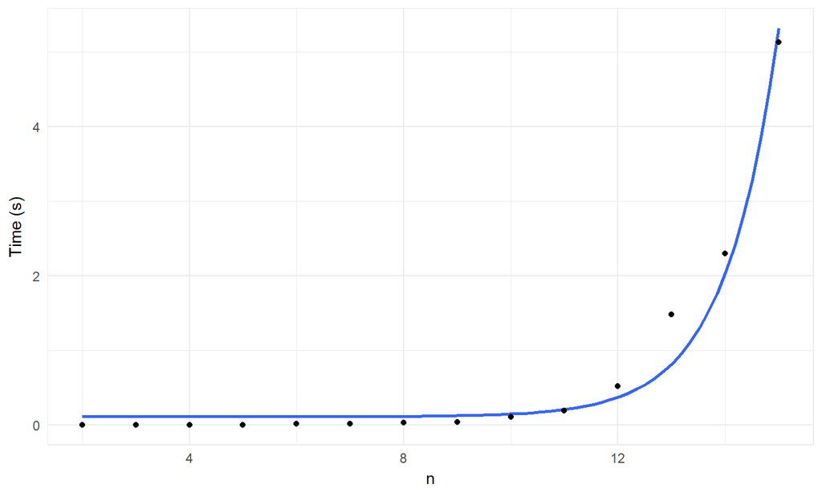

## Conclusion:

## Results:

- Effectively allows you to test a hypothesis involving nearly any statistic, without the need to derive an underlying distribution
- By freeing oneself of this need, the assumptions for running such a test are relaxed
  - This can be especially helpful for cases with \(n<20\), as when examining the mean, the Central Limit Theorem may not have kicked in yet
- A drawback of this method is it is typically not the optimal solution in most cases
- Unless carefully written, Randomization tests can be quite computationally intensive
  - `permPT`

## References

Conover, W. J. (1999). Practical nonparametric statistics (3rd ed.). John Wiley & Sons.

Fay, M. (2010, July 29). Perm: Exact or Asymptotic permutation tests. Retrieved November 29, 2017, from https://cran.r-project.org/package=perm